# What a Question About the Economy Measures

One economy, one question, and an answer that changes sign every time the White House changes party

Democracy’s Data

Last updated September 13, 2026 at 10:53a EDT

There is one American economy. In any given year it grew or it shrank, and that is true no matter who you ask. A question about the economy is therefore not like a question about abortion or ideology, where people disagreeing *is* the measurement. It looks like a question with a fact sitting behind it. So this brief asks the question that look invites: do Americans agree on how the economy is doing?

The American National Election Studies — ANES, the academic survey that has interviewed a national sample of Americans, a few thousand people chosen at random to stand in for the country, in every presidential election since 1948 — has asked it in every study since 1980. In 2024, 28.3% of Democrats said the national economy had got worse over the past year. Among Republicans it was 82.5%. That is a gap of 54.2 points, on a question about a country both groups live in. Four years earlier the same question produced a gap of 40.6 points **the other way**.

## The test

The measure is what political scientists call a **retrospective evaluation** — a judgment that looks backward rather than forward: did the nation’s economy get better or worse over the past year. The idea that voters judge a government on results already delivered, rather than on promises, is one of the oldest in the study of elections.[^1] The question sits in the ANES Time Series Cumulative Data File, 1948–2024, a single table collected by the University of Michigan and Stanford University for the American National Election Studies, which stacks every study since 1948 into one file. It is free, but must be requested through a browser with an account at [electionstudies.org](https://electionstudies.org/data-center/anes-time-series-cumulative-data-file/). The question has been asked in 18 studies since 1980, in the same words. The ANES chapter introduces the cumulative file and what it costs to get; this brief pulls two of its questions out.

This question looks like the exception to a rule that runs through this section. Most opinion measures are never graded — no election, no count, no official record ever arrives to score them, so the survey’s method has to be the whole credential. Here a record exists: the national accounts — the government’s own ledger of what the economy produced each year, kept by the [Bureau of Economic Analysis](https://www.bea.gov/data/gdp/gross-domestic-product) — say what the economy did, and the answers could in principle be marked against them. This brief never marks them, because its finding needs no outside record at all. What it needs is a series: the same words asked across five decades. That exists only because ANES kept asking them, study after study.

The test is a subtraction with a prediction attached. For every study year, take the share of Democrats saying the economy got worse, subtract the share of Republicans saying so, and set the sign of the result against the party holding the White House. Then two follow-ups: split the same answers seven ways instead of two, and run the identical subtraction on a question about the respondent’s own household.

## The data

Two columns arrive in the same interview, and the codebook gives them in these words.

```
Two questions, asked in the same interview, in the codebook's words.

  VCF0870  BETTER OR WORSE ECONOMY IN PAST YEAR
    Now thinking about the economy in the country as a whole, would
    you say that over the past year the nation's economy has gotten
    better, stayed about the same or gotten worse?

      1. Better     3. Stayed same     5. Worse

  VCF0880  BETTER OR WORSE OFF IN PAST YEAR
    We are interested in how people are getting along financially
    these days. Would you say that you (and your family living here)
    are better off or worse off financially than you were a year ago?

      1. Better Now     2. Same     3. Worse Now

The two do not share a code for 'worse'. One uses 5, the other 3.

Five real rows. VCF0303 is the file's own three-way party column.

year  VCF0303  party  VCF0870  VCF0880
1994  1  Democrat  1  1
1998  3  Republican  1  3
2012  3  Republican  5  3
2020  2  Independent  5  3
2024  1  Democrat  1  2

Nothing in either column records who was president when it was asked.
That is the fact the two columns turn out to be about.
```

Read the two code lists again. The first question numbers *worse* as 5 and the second numbers it as 3. Nothing warns you. Treat the second column the way you treated the first and every worse answer silently disappears — a mistake that would survive every visual inspection, because both columns look like small tidy integers.

Party comes from `VCF0303`, the file’s own three-way column. It takes the people who call themselves independent and then admit to leaning, and files them with the party they lean toward. That is a decision rather than a fact, and it is the decision the party identification brief is about. It is the right one here, and Figure 2 below is part of the reason why.

Four tables are built from these columns. `national.csv` holds, for each study year, the share of Democrats, independents and Republicans saying the national economy got worse, the party of the president, the group sizes, and the `gap`. `personal.csv` holds the same arithmetic for the household question. `gradient.csv` breaks 2020 and 2024 out by the full seven-point party scale. `weighting.csv` recomputes every gap with the file’s weight applied, because the main tables leave it off. To weight is to count some answers more than others, so that the sample’s mix of ages, races, regions and so on matches the country’s; the targets come from the census.

> **Before you read on, commit to a number.** In 2024 a Democratic president was in office. Write down what you think the gap was between Democrats and Republicans on whether the *national economy* had got worse — and then write down what you think it was on whether **their own household finances** had got worse. You will see both.

## What it says about democracy

Here is the subtraction for every study from 1980 to 2024: the share of Democrats who said worse, minus the share of Republicans, in percentage points.

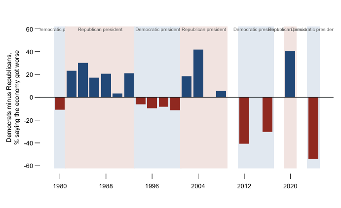

**Figure 1. The partisan gap on the national economy, 1980–2024.** Bars on a time axis, because the claim is about the *sign* of one number per year, and a bar makes a sign visible at a glance. The shaded bands behind the bars are the party of the president when the interviews were done. A bar above the line means Democrats were the more negative group; below it means Republicans were. Hovering gives the two shares each bar is built from, and how many people answered in each group.

The bar points up in every Republican year and down in every Democratic year. That holds in 18 of 18 studies, with no exception in 18 election cycles and six changes of party in the White House.

| Year | President | Democrats saying worse | Republicans saying worse | Gap |
| --- | --- | --- | --- | --- |
| 1980 | Democratic | 79.1% | 89.9% | -10.8 pts |
| 1992 | Republican | 80.7% | 59.8% | 20.9 pts |
| 2000 | Democratic | 10.2% | 21.6% | -11.4 pts |
| 2008 | Republican | 91.7% | 86.2% | 5.5 pts |
| 2020 | Republican | 79.9% | 39.3% | 40.6 pts |
| 2024 | Democratic | 28.3% | 82.5% | -54.2 pts |

Read the last two rows as the arithmetic they are. In 2020, with a Republican in the White House, 79.9% of Democrats said the economy had got worse and 39.3% of Republicans did. Subtract the second from the first: 79.9 − 39.3 = 40.6 points. The number is positive, so the bar points up, and the president’s opponents were the gloomier group. In 2024, with a Democrat in office, the same subtraction is 28.3 − 82.5 = -54.2. Negative, so the bar points down — and again the president’s opponents are the gloomier group. That is the whole test, applied 18 times.

Notice that the levels move too, not just the gap. In 2020, 79.9% of Democrats said the economy had got worse. Four years later 28.3% did. The same group, the same question, an economy that had grown in both windows, and a 51.6-point swing.

Split the same question seven ways instead of three — along the ANES party scale, which runs from strong Democrat through weak and leaning Democrat, pure independent, and leaning and weak Republican, to strong Republican — and you can see how orderly the reversal is.

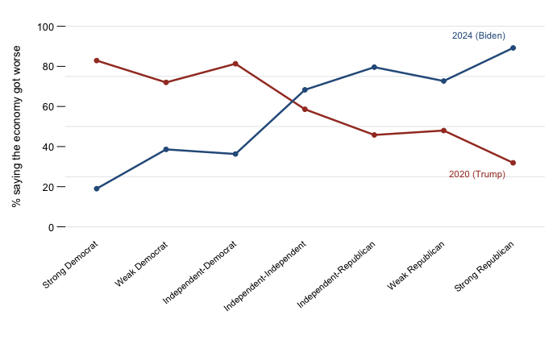

**Figure 2. The same question, seven groups, two adjacent studies.** In HTML the buttons drop one year so the other can be read on its own; hovering gives the count behind each point.

In 2020 the line runs downhill: strong Democrats were the most negative group at 82.9% and strong Republicans the least at 31.9%. In 2024 it runs uphill, from 19.0% among strong Democrats to 89.2% among strong Republicans. The order of the seven groups did not scramble. It turned over.

Two details are worth stopping on. People who claimed no party at all sit near the middle in both years, which is what you would expect if partisanship is what moves the line. The leaners sit out near the partisans instead — the same finding the party identification brief reaches from vote choice, arrived at from a different column.

There is a real objection to all of this. Democrats and Republicans are not the same people. They differ in income, age, region and industry, so they may be describing genuinely different economic experiences rather than reporting the same country differently.

The file can answer that, because the same interview asks a second question: are **you** better or worse off financially than you were a year ago. The national economy has one true answer for everybody; household finances have millions of true answers, and Democratic and Republican households really do differ. So if the gap were composition — a matter of who the two parties are made of, rather than of how they see the same country — the personal question should carry the bigger one. It does not.

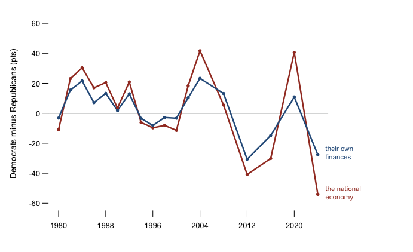

**Figure 3. Two subtractions, same people, same interviews.** Hovering reports both gaps for a year and says which question is the wider of the two.

| Year | The national economy | Their own finances | Wider on |
| --- | --- | --- | --- |
| 1984 | 30.3 pts | 21.6 pts | the national question |
| 2004 | 41.7 pts | 23.3 pts | the national question |
| 2008 | 5.5 pts | 13.2 pts | their own finances |
| 2016 | -30.2 pts | -14.8 pts | the national question |
| 2020 | 40.6 pts | 10.9 pts | the national question |
| 2024 | -54.2 pts | -27.7 pts | the national question |

The gap on the national economy is wider than the gap on people’s own finances in 17 of 18 studies. Both cross zero in the same years, so partisanship reaches the household question too. It just reaches it with about half the force. That is the finding: the question with one true answer splits the parties further apart than the question with millions of them.

The exceptions get their story, and it is one story. The two narrowest gaps in the series are 1990 and 2008 — the recession of the early 1990s and the financial crisis of 2008.[^2] In 2008, 91.7% of Democrats and 86.2% of Republicans said the economy had got worse, which leaves very little room for a gap. 2008 is also the one year in Figure 3 where the personal question splits the parties wider than the national one. Both facts have the same cause: when an economy is bad enough, almost everybody says so, and the national question runs out of room before partisanship does.

## What this brief cannot tell you

It cannot tell you which party is right. The brief never compares these answers to what the economy actually did, so nothing here says that one side reads the country correctly and the other does not. Both groups move when the White House changes hands,[^3] and the figures show the distance between them rather than the distance from the truth.

It cannot tell you what people believe. A survey records what somebody said to an interviewer. Saying the economy is bad under the other party’s president may be a sincere belief, a rough way of saying you dislike the president, or something closer to cheering for a team. Those are different things and this file cannot separate them. Political scientists call the first possibility **partisan-motivated reasoning** — arriving at the conclusion your party would want and then finding the reasons for it — and the pattern in Figure 1 is its textbook illustration.[^4] One way to tell belief from cheering is to pay respondents for accurate answers; when that has been tried, the partisan gap on factual questions narrowed considerably but did not vanish.[^5]

It cannot tell you that nothing real is in these answers. Partisans do differ in where they live and what they do for work, and a policy can genuinely help one group before another. The personal-finance comparison shows that composition is too small to account for the national gap. It does not show that composition is zero.

Nothing in the main tables is weighted; `VCF0009z` sits in the file unused there. Because that caveat is easy to write and hard to trust, every gap was also recomputed with the weight applied. No sign changes, and the largest difference to any year is 3.9 points.

Finally, the president is not the only thing that changes when the White House changes party. Congress, the news, and the economy itself all move at the same time. The pattern in Figure 1 is as clean as survey evidence gets, and it is still a pattern in 18 observations rather than an experiment.

## What you should have learned

- The sign of the partisan gap on the national economy has matched the party of the president in 18 of 18 studies: the president’s opponents are always the more negative group.
- The gap is not small: 54.2 points in 2024, and 40.6 points the other way in 2020, on a question about a country both groups live in.
- The same interview’s question about the respondent’s own finances carries a smaller partisan gap in 17 of 18 studies — the question with one true answer divides the parties more than the question with millions.
- The exceptions are the worst economies: in 2008, 91.7% of Democrats and 86.2% of Republicans said worse, and near-unanimity leaves no room for a gap.
- Weighting rescues none of it: no gap changes sign, and the largest change to any year is 3.9 points.

## Extensions

None of these is answered above, and every one can be answered from the tables the Sources section hands over.

- `national.csv` has `ind_worse`, the independents’ share saying worse, which no figure above draws. Follow it across the years. Does it track the president’s opponents, the president’s side, or neither?
- `personal.csv` has its own `gap` for every year. Find the years where it comes closest to the national one, and ask what those years have in common.
- `gradient.csv` breaks 2020 and 2024 out by the seven-point scale, with `respondents` behind each point. Compare the leaners against the weak partisans on `pct_worse`. Which do they resemble?
- `weighting.csv` reports `gap_unweighted`, `gap_weighted` and the `difference`. Find the year weighting matters most, and check whether it is a thin-sample year in `national.csv`.

Two stretch ideas point past the spreadsheet. The [Bureau of Economic Analysis](https://www.bea.gov/data/gdp/gross-domestic-product) publishes annual GDP growth; line it up against `national.csv` and ask which predicts the answers better, the economy or the White House. And the University of Michigan’s [Surveys of Consumers](https://data.sca.isr.umich.edu/) publishes consumer sentiment by party — find a recent release and check whether its gap flips at the same inaugurations Figure 1’s does.

## Sources

**Data**

- American National Election Studies. *ANES Time Series Cumulative Data File (1948–2024)*, version of 5 February 2026. Ann Arbor, MI and Palo Alto, CA: University of Michigan and Stanford University. https://electionstudies.org/data-center/anes-time-series-cumulative-data-file/ The file must be requested through a browser with a free account, and is not redistributed with this book; the ANES chapter describes what it costs to get.
- ANES. *Time Series Cumulative Data File Codebook*, same release. The wording of `VCF0870` and `VCF0880`, and both code lists, are quoted from it.
- **Checks.** Every value this brief quotes is asserted against the four tables below each time the document is rendered. The table of assertions is printed here verbatim:

| Check | Value |
| --- | --- |
| study years carrying the national economy question | 18 |
| years where the sign of the gap matches the president’s party | 18 of 18 |
| years where the personal-finance gap is smaller than the national one | 17 of 18 |
| the only year where it is not | 2008 |
| years where the two gaps point the same direction | 18 of 18 |
| the two narrowest gaps in the series | 1990 and 2008 |
| 2020: strong Democrats minus strong Republicans, points | 51 |
| 2024: the same subtraction, points | -70.2 |
| years where weighting changes the sign of the gap | 0 |
| largest difference weighting makes to any gap, points | 3.9 |

**Academic literature**

- Fiorina, Morris P. (1981). *Retrospective Voting in American National Elections.* Yale University Press. The idea that voters grade governments on results already delivered. https://yalebooks.yale.edu/book/9780300025576/retrospective-voting-in-american-national-elections/
- Bartels, Larry M. (2002). “Beyond the Running Tally: Partisan Bias in Political Perceptions.” *Political Behavior* 24(2): 117–150. https://doi.org/10.1023/A:1021226224601
- Gerber, Alan S. and Gregory A. Huber (2010). “Partisanship, Political Control, and Economic Assessments.” *American Journal of Political Science* 54(1): 153–173. https://www.jstor.org/stable/20647977
- Bullock, John G., Alan S. Gerber, Seth J. Hill and Gregory A. Huber (2015). “Partisan Bias in Factual Beliefs about Politics.” *Quarterly Journal of Political Science* 10(4): 519–578, doi:10.1561/100.00014074. On how much of a gap like this survives when respondents are paid for accuracy.

**The data itself**

Every figure above is drawn from these tables. They are plain CSV, they open in a spreadsheet, and they are yours to take further.

`gradient.csv`, `national.csv`, `personal.csv`, `weighting.csv`

One more file is not data about the subject – it is how this chapter checked its own work: `checks.csv`, the arithmetic verified before anything was drawn.

[^1]: Morris P. Fiorina, *Retrospective Voting in American National Elections* (New Haven: Yale University Press, 1981), https://yalebooks.yale.edu/book/9780300025576/retrospective-voting-in-american-national-elections/.
[^2]: The National Bureau of Economic Research dates the two recessions to July 1990–March 1991 and December 2007–June 2009: https://www.nber.org/research/data/us-business-cycle-expansions-and-contractions.
[^3]: The same reversal at the same moments, in a different design: Alan S. Gerber and Gregory A. Huber, “Partisanship, Political Control, and Economic Assessments,” *American Journal of Political Science* 54, no. 1 (2010): 153–173, https://www.jstor.org/stable/20647977.
[^4]: Larry M. Bartels, “Beyond the Running Tally: Partisan Bias in Political Perceptions,” *Political Behavior* 24, no. 2 (2002): 117–150, https://doi.org/10.1023/A:1021226224601.
[^5]: John G. Bullock, Alan S. Gerber, Seth J. Hill and Gregory A. Huber, “Partisan Bias in Factual Beliefs about Politics,” *Quarterly Journal of Political Science* 10, no. 4 (2015): 519–578, doi:10.1561/100.00014074.